# 5.3 Summarizing and Computing Descriptive Statistics

- Pandas objects are equipped with a set of common mathematical and statistical methods.
- Compared with the similar methods found on NumPy arrays, **they have built-in handling for missing data.**

```python
import numpy as np
import pandas as pd
```

```python
df = pd.DataFrame([[1.4, np.nan], [7.1, -4.5],[np.nan, np.nan], [0.75, -1.3]],\
             index=['a', 'b', 'c', 'd'],columns=['one', 'two'])
df
```

|  | one | two |
| --- | --- | --- |
| a | 1.40 | NaN |
| b | 7.10 | -4.5 |
| c | NaN | NaN |
| d | 0.75 | -1.3 |

Calling DataFrame’s `sum` method returns a Series containing **column sums**:

```python
df.sum()
```

```
one    9.25
two   -5.80
dtype: float64
```

Passing `axis='columns'` or `axis=1` sums across the columns instead:

```python
df.sum(axis='columns')
```

```
a    1.40
b    2.60
c    0.00
d   -0.55
dtype: float64
```

NA values are excluded unless the entire slice (row or column in this case) is NA. This can be disabled with the `skipna` option:

```python
df.mean(axis='columns', skipna=False)
```

```
a      NaN
b    1.300
c      NaN
d   -0.275
dtype: float64
```

#### See Table 5-7 for a list of common options for each reduction method.

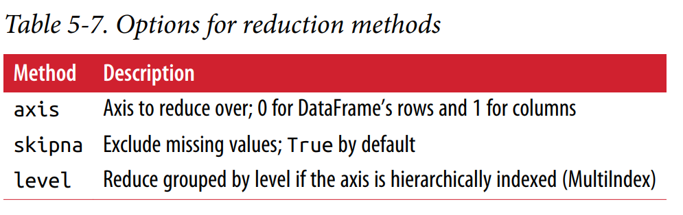

Some methods, like `idxmin` and `idxmax`, return indirect statistics like the index value where the minimum or maximum values are attained:

```python
df.idxmax()
```

```
one    b
two    d
dtype: object
```

Other methods are **accumulations:**

```python
df.cumsum()
```

|  | one | two |
| --- | --- | --- |
| a | 1.40 | NaN |
| b | 8.50 | -4.5 |
| c | NaN | NaN |
| d | 9.25 | -5.8 |

`describe` producing multiple summary statistics in one shot:

```python
df.describe()
```

|  | one | two |
| --- | --- | --- |
| count | 3.000000 | 2.000000 |
| mean | 3.083333 | -2.900000 |
| std | 3.493685 | 2.262742 |
| min | 0.750000 | -4.500000 |
| 25% | 1.075000 | -3.700000 |
| 50% | 1.400000 | -2.900000 |
| 75% | 4.250000 | -2.100000 |
| max | 7.100000 | -1.300000 |

**On non-numeric data**, describe produces alternative summary statistics:

```python
obj = pd.Series(['a', 'a', 'b', 'c'] * 4)
obj.describe()
```

```
count     16
unique     3
top        a
freq       8
dtype: object
```

#### See Table 5-8 for a full list of summary statistics and related methods.

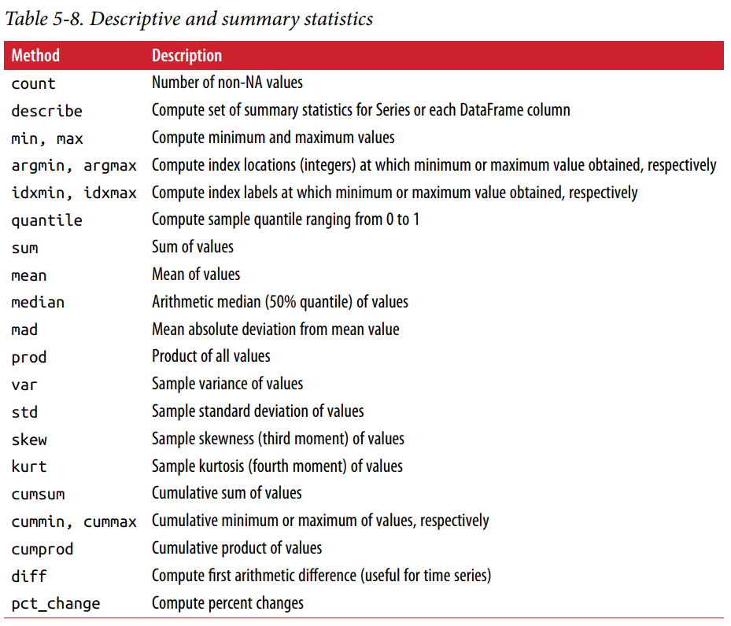

### 1. Correlation and Covariance

```python
# !conda install pandas-datareader
```

```python
import pandas_datareader.data as web
from pandas.util.testing import assert_frame_equal
all_data = {ticker: web.get_data_yahoo(ticker) for ticker in ['AAPL', 'IBM', 'MSFT', 'GOOG']}
```

```python
price = pd.DataFrame({ticker: data['Adj Close'] for ticker, data in all_data.items()})
volume = pd.DataFrame({ticker: data['Volume'] for ticker, data in all_data.items()})
```

#### Now compute percent changes of the prices

```python
returns = price.pct_change() * 100
returns.tail()
```

| Date | AAPL | IBM | MSFT | GOOG |
| --- | --- | --- | --- | --- |
| 2020-07-06 | 2.675022 | 0.409361 | 2.152624 | 2.116474 |
| 2020-07-07 | -0.310286 | -2.171562 | -1.162789 | -0.703343 |
| 2020-07-08 | 2.329011 | 0.110561 | 2.199281 | 0.728528 |
| 2020-07-09 | 0.430032 | -1.699091 | 0.700092 | 1.002005 |
| 2020-07-10 | 0.174926 | 2.281565 | -0.303289 | 2.035090 |

The `corr` method of Series computes the *correlation* of the overlapping, non-NA, aligned-by-index values in two Series. Relatedly, `cov` computes the *covariance*:

```python
returns['MSFT'].corr(returns['IBM'])
```

```
0.593161817067868
```

```python
returns['MSFT'].cov(returns['IBM'])
```

```
1.6660175252734752
```

We can also select these columns using more concise syntax:

```python
returns.MSFT.corr(returns.IBM)
```

```
0.593161817067868
```

DataFrame’s `corr` and `cov` methods, on the other hand, **return a full correlation or covariance matrix as a DataFrame**, respectively

```python
returns.corr()
```

|  | AAPL | IBM | MSFT | GOOG |
| --- | --- | --- | --- | --- |
| AAPL | 1.000000 | 0.527378 | 0.716384 | 0.646162 |
| IBM | 0.527378 | 1.000000 | 0.593162 | 0.526100 |
| MSFT | 0.716384 | 0.593162 | 1.000000 | 0.751614 |
| GOOG | 0.646162 | 0.526100 | 0.751614 | 1.000000 |

Using DataFrame’s `corrwith` method, you can **compute pairwise correlations between a DataFrame’s columns or rows with another Series or DataFrame.**

```python
returns.corrwith(returns.IBM)
```

```
AAPL    0.527378
IBM     1.000000
MSFT    0.593162
GOOG    0.526100
dtype: float64
```

```python
returns.corrwith(volume)
```

```
AAPL   -0.139780
IBM    -0.115935
MSFT   -0.065446
GOOG   -0.050404
dtype: float64
```

Passing axis='columns' does things row-by-row instead. In all cases, the data points are aligned by label before the correlation is computed.

### 2. Unique Values, Value Counts, and Membership

Another class of related methods **extracts information about the values contained in a one-dimensional Series**. To illustrate these, consider this example:

```python
obj = pd.Series(['c', 'a', 'd', 'a', 'a', 'b', 'b', 'c', 'c'])
```

The first function is `unique`, which gives you an array of the unique values in a Series:

```python
uniques = obj.unique()
uniques
```

```
array(['c', 'a', 'd', 'b'], dtype=object)
```

Relatedly, **`value_counts` computes a Series containing value frequencies:**

```python
obj.value_counts()
```

```
c    3
a    3
b    2
d    1
dtype: int64
```

`value_counts` is also available as a top-level pandas method that can be used with any array or sequence:

```python
pd.value_counts(obj.values, sort=False)
```

```
b    2
a    3
d    1
c    3
dtype: int64
```

**`isin` performs a vectorized set membership check and can be useful in filtering a dataset down to a subset of values** in a Series or column in a DataFrame:

```python
print(obj)
mask = obj.isin(['b', 'c'])
```

```
0    c
1    a
2    d
3    a
4    a
5    b
6    b
7    c
8    c
dtype: object
```

```python
mask
```

```
0     True
1    False
2    False
3    False
4    False
5     True
6     True
7     True
8     True
dtype: bool
```

```python
obj[mask]
```

```
0    c
5    b
6    b
7    c
8    c
dtype: object
```

Related to `isin` is the `Index.get_indexer` method, which **gives you an index array from an array of possibly non-distinct values into another array of distinct values:**

```python
to_match = pd.Series(['c', 'a', 'b', 'b', 'c', 'a'])
unique_vals = pd.Series(['c', 'b', 'a'])
pd.Index(unique_vals).get_indexer(to_match)
```

```
array([0, 2, 1, 1, 0, 2], dtype=int64)
```

#### See Table 5-9 for a reference on these methods

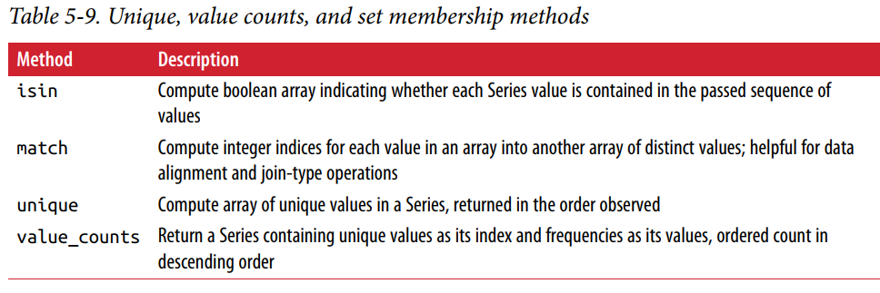

In some cases, you may want to compute a histogram on multiple related columns in a DataFrame. Here’s an example:

```python
data = pd.DataFrame({'Qu1': [1, 3, 4, 3, 4],'Qu2': [2, 3, 1, 2, 3],'Qu3': [1, 5, 2, 4, 4]})
data
```

|  | Qu1 | Qu2 | Qu3 |
| --- | --- | --- | --- |
| 0 | 1 | 2 | 1 |
| 1 | 3 | 3 | 5 |
| 2 | 4 | 1 | 2 |
| 3 | 3 | 2 | 4 |
| 4 | 4 | 3 | 4 |

Passing `pandas.value_counts` to this DataFrame’s `apply` function gives:

```python
result = data.apply(pd.value_counts).fillna(0)
result
```

|  | Qu1 | Qu2 | Qu3 |
| --- | --- | --- | --- |
| 1 | 1.0 | 1.0 | 1.0 |
| 2 | 0.0 | 2.0 | 1.0 |
| 3 | 2.0 | 2.0 | 0.0 |
| 4 | 2.0 | 0.0 | 2.0 |
| 5 | 0.0 | 0.0 | 1.0 |